# Reproducible Research: Peer Assessment 1

## Loading and preprocessing the data

The first step consists in load the data from the zip file, available in the folder.

```r
#Unzip the file and load the data
unzip(zipfile="activity.zip")
data_raw <- read.csv("activity.csv")
```

## What is mean total number of steps taken per day?

For the first considerations I will ignore the NA value.

At first I have calculate the number of step taken per day:

```r
num_step_day <- aggregate(data_raw$steps, by=list(data_raw$date), sum)
```

Here we can see an histogram that represents the frequency of total number of steps taken each day:

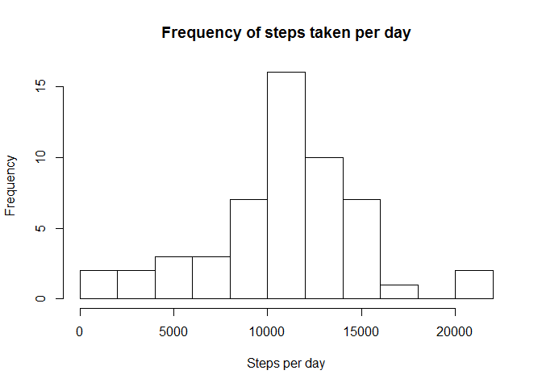

```r
hist(num_step_day$x, main="Frequency of steps taken per day", xlab="Steps per day", breaks=10)
```

Eventualy I have calculated the mean and the median of the total number of steps taken per day:

```r
mean_step_day <- mean(num_step_day$x, na.rm =TRUE)
median_step_day <- median(num_step_day$x, na.rm =TRUE)
```

The mean of steps taken per day is:

```r
format(mean_step_day, digits=2, nsmall=1)
```

```
## [1] "10766.2"
```

The median of steps taken per day is:

```r
format(median_step_day, digits=2, nsmall=1)
```

```
## [1] "10765"
```

## What is the average daily activity pattern?

For this point I made a time series plot of the 5-minute interval (x-axis) and the average number of steps taken, averaged across all days (y-axis):

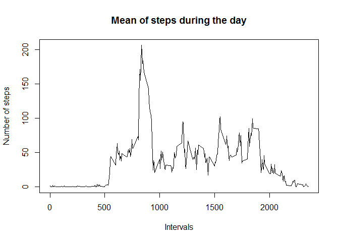

```r
mean_step_interval <- aggregate(data_raw$steps, by=list(data_raw$interval), FUN=mean, na.rm=TRUE)

plot(mean_step_interval$Group.1, mean_step_interval$x, type="l", xlab="Intervals", ylab="Number of steps", main="Mean of steps during the day")
```

Eventualy I have calculated the 5-minute interval that contains the maximum number of steps (on average across all the days in the dataset):

```r
max_step_interval <- max(mean_step_interval$x, na.rm=TRUE)
max_interval <- mean_step_interval[mean_step_interval$x == max_step_interval, 1]
```

The 5-minute interval with the maximum number of steps in average is:

```r
max_interval
```

```
## [1] 835
```